# Seal AA3

Engels Guyliann

2019-02-14

La fonction de base ne sait pas importer le jeux de données

# 1 Métadonnées

```
## $sample
## [1] "190213A-orga"
##
## $project
## NULL
##
## $sample_date
## [1] "2019-02-13 14:04:12 UTC"
##
## $author
## [1] "Antoine"
##
## $date
## [1] "2019-02-13"
##
## $comment
## [1] "test"
##
## $topic
## NULL
```

# 2 Méthode

|  | method | unit | base | gain | lamp |
| --- | --- | --- | --- | --- | --- |
| channel_1 | Ptot | µmol/L | -5596 | 161 | 253 |
| channel_2 | Ntot | µmol/L | -7430 | 15 | 300 |
| channel_3 | NO2 | µmol/L | -7693 | 21 | 289 |

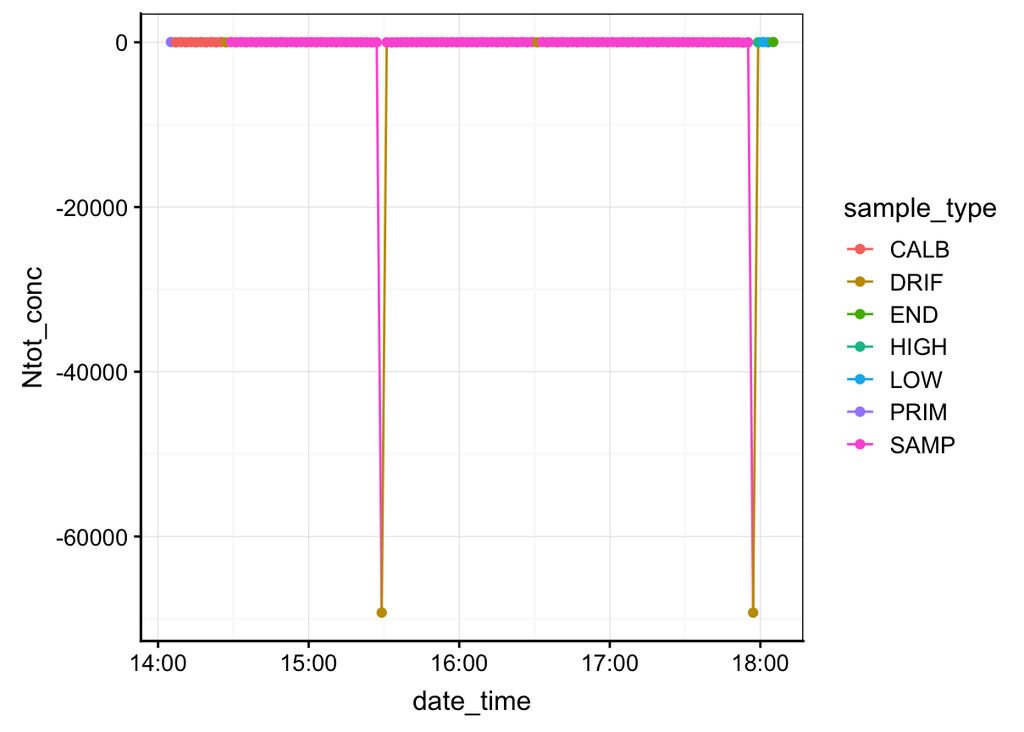

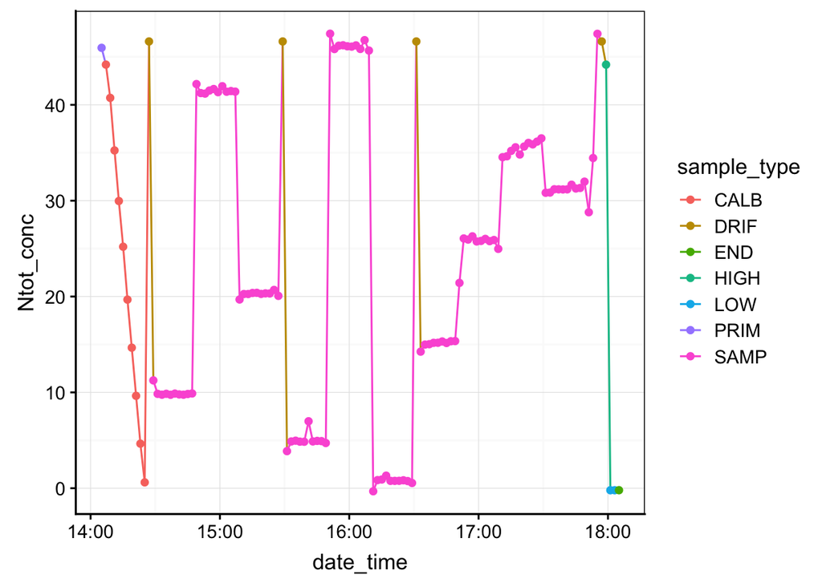

Après correction du fichier sur le seal aa3, les résultats suivants sont obtenus

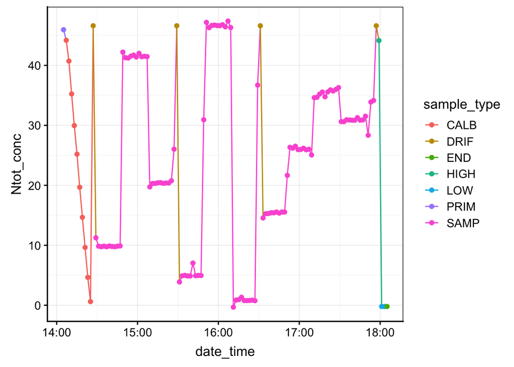

| sample_id | mean | sd | cv | n |
| --- | --- | --- | --- | --- |
| cal1 | 4.010818 | 10.8519595 | 2.7056723 | 11 |
| cal10 | 9.936727 | 0.4416859 | 0.0444498 | 11 |
| cal15 | 15.844454 | 1.9585328 | 0.1236100 | 11 |
| cal20 | 20.799273 | 1.7627233 | 0.0847493 | 11 |
| cal25 | 26.726000 | 2.6533728 | 0.0992806 | 11 |
| cal30 | 30.638818 | 0.8523893 | 0.0278206 | 11 |
| cal35 | 35.053000 | 1.5514009 | 0.0442587 | 11 |
| cal40 | 41.504909 | 0.3957255 | 0.0095344 | 11 |
| cal45 | 46.474273 | 0.8268284 | 0.0177911 | 11 |
| cal5 | 7.366273 | 7.8528874 | 1.0660598 | 11 |
| mesoA | 33.890000 | NA | NA | 1 |
| mesoB | 34.153000 | NA | NA | 1 |

Pour le Ntot nous obtenons,

Après une discussion sur les résultats, on pense que les droites de calibration ne sont pas correcte. Nous calculons une nouvelle droite de régression.

```
##
## Call:
## lm(formula = Ntot_values ~ Ntot_std, data = filter(df3, sample_type ==
##     "CALB"))
##
## Residuals:
##       1       2       3       4       5       6
## -848.43  829.14  276.71  -47.71  190.86 -400.57
##
## Coefficients:
##             Estimate Std. Error t value Pr(>|t|)
## (Intercept)  3734.29    1042.09   3.583   0.0231 *
## Ntot_std     1103.31      31.01  35.577 3.73e-06 ***
## ---
## Signif. codes:  0 '***' 0.001 '**' 0.01 '*' 0.05 '.' 0.1 ' ' 1
##
## Residual standard error: 648.7 on 4 degrees of freedom
##   (4 observations deleted due to missingness)
## Multiple R-squared:  0.9968, Adjusted R-squared:  0.9961
## F-statistic:  1266 on 1 and 4 DF,  p-value: 3.725e-06
```

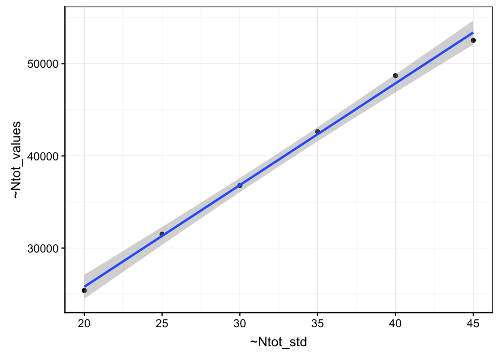

On observe que le cv diminue pour l’ensemble des concentrations testées.

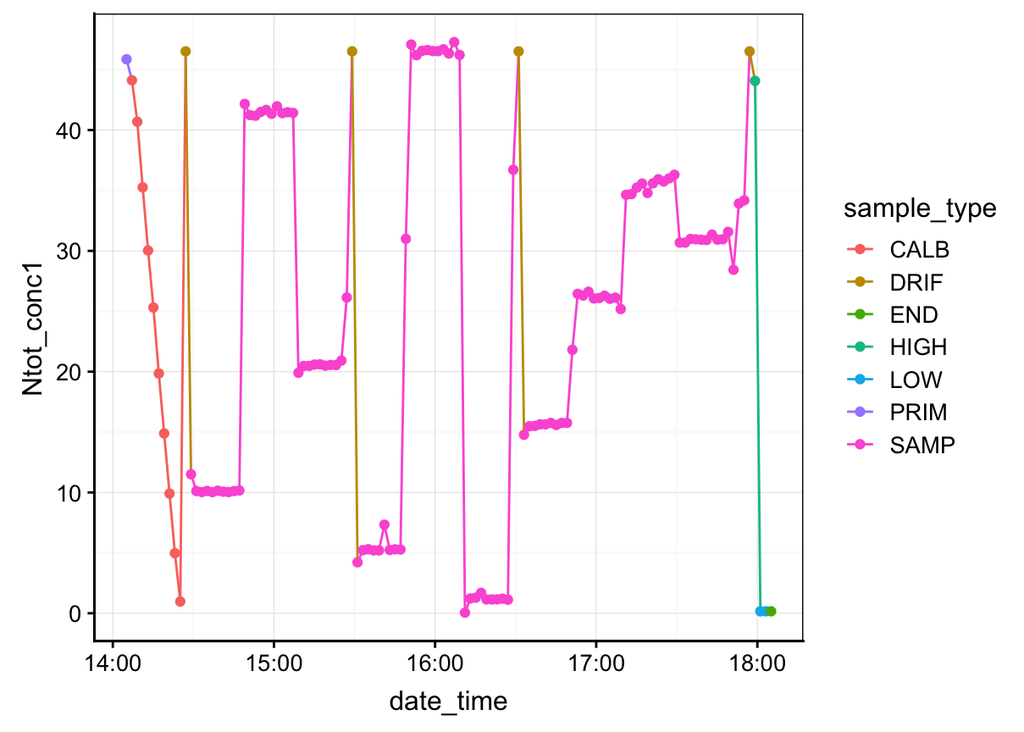

| sample_id | mean | sd | cv | n |
| --- | --- | --- | --- | --- |
| cal1 | 4.337447 | 10.7440528 | 2.4770454 | 11 |
| cal10 | 10.204535 | 0.4374132 | 0.0428646 | 11 |
| cal15 | 16.053489 | 1.9390593 | 0.1207874 | 11 |
| cal20 | 20.959197 | 1.7451605 | 0.0832647 | 11 |
| cal25 | 26.827099 | 2.6270506 | 0.0979253 | 11 |
| cal30 | 30.701083 | 0.8440665 | 0.0274931 | 11 |
| cal35 | 35.071372 | 1.5360524 | 0.0437979 | 11 |
| cal40 | 41.459160 | 0.3919940 | 0.0094549 | 11 |
| cal45 | 46.379262 | 0.8186244 | 0.0176507 | 11 |
| cal5 | 7.659504 | 7.7749122 | 1.0150674 | 11 |
| mesoA | 33.920431 | NA | NA | 1 |
| mesoB | 34.180741 | NA | NA | 1 |

La correction de la droite de calibration n’est pas suffisante pour améliorer la précision des mesures réalisées sur Ntot. Il faut prévoir une correction sur l’instrument des points problématiques.

Pour le Ptot, nous obtenons

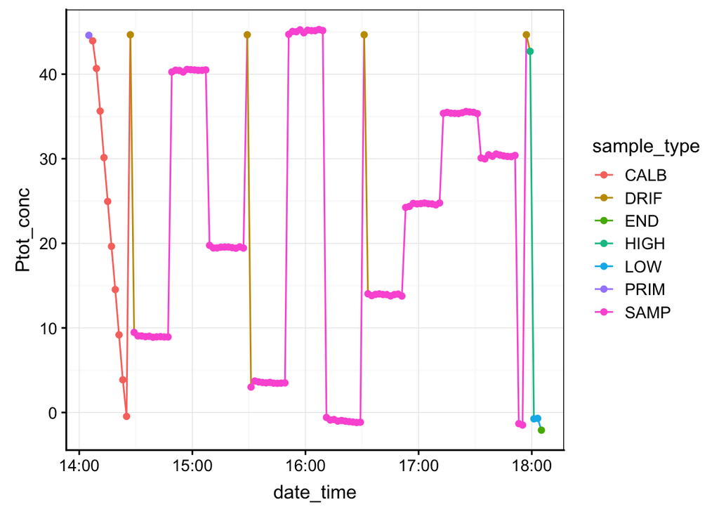

| sample_id | mean | sd | cv | n |
| --- | --- | --- | --- | --- |
| cal1 | -0.9363636 | 0.2327596 | -0.2485783 | 11 |
| cal10 | 9.0350909 | 0.1641246 | 0.0181652 | 11 |
| cal15 | 13.9762727 | 0.2066035 | 0.0147824 | 11 |
| cal20 | 19.5375455 | 0.1001772 | 0.0051274 | 11 |
| cal25 | 24.6433636 | 0.1963106 | 0.0079661 | 11 |
| cal30 | 30.2934545 | 0.1734124 | 0.0057244 | 11 |
| cal35 | 35.4543636 | 0.1003925 | 0.0028316 | 11 |
| cal40 | 40.4656364 | 0.1222581 | 0.0030213 | 11 |
| cal45 | 44.9818182 | 0.3813035 | 0.0084768 | 11 |
| cal5 | 3.5187273 | 0.2117357 | 0.0601740 | 11 |
| mesoA | -1.3200000 | NA | NA | 1 |
| mesoB | -1.4840000 | NA | NA | 1 |

Après une discussion sur les résultats, on pense que les droites de calibration ne sont pas correcte. La droite de calibration rouge représente les points employés afin de calculer la droite de régression employé par le seal aa3

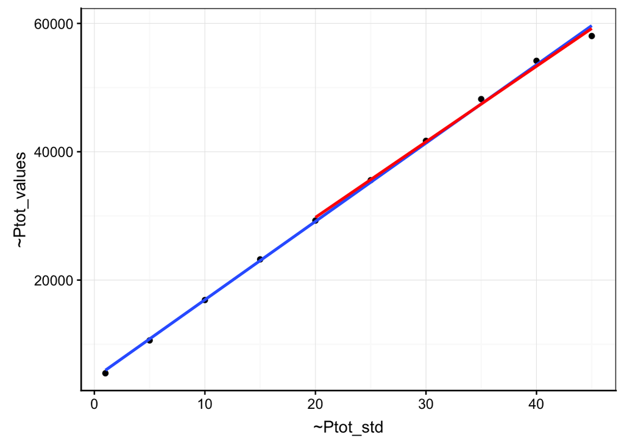

Nous recalculons de ce fait les valeurs de concentration

```
##
## Call:
## lm(formula = Ptot_values ~ Ptot_std, data = filter(df3, sample_type ==
##     "CALB"))
##
## Residuals:
##     Min      1Q  Median      3Q     Max
## -1621.7  -183.8   162.4   342.9   755.4
##
## Coefficients:
##             Estimate Std. Error t value Pr(>|t|)
## (Intercept)  4725.52     426.90   11.07 3.96e-06 ***
## Ptot_std     1220.72      15.99   76.33 9.67e-13 ***
## ---
## Signif. codes:  0 '***' 0.001 '**' 0.01 '*' 0.05 '.' 0.1 ' ' 1
##
## Residual standard error: 718.5 on 8 degrees of freedom
## Multiple R-squared:  0.9986, Adjusted R-squared:  0.9985
## F-statistic:  5827 on 1 and 8 DF,  p-value: 9.669e-13
```

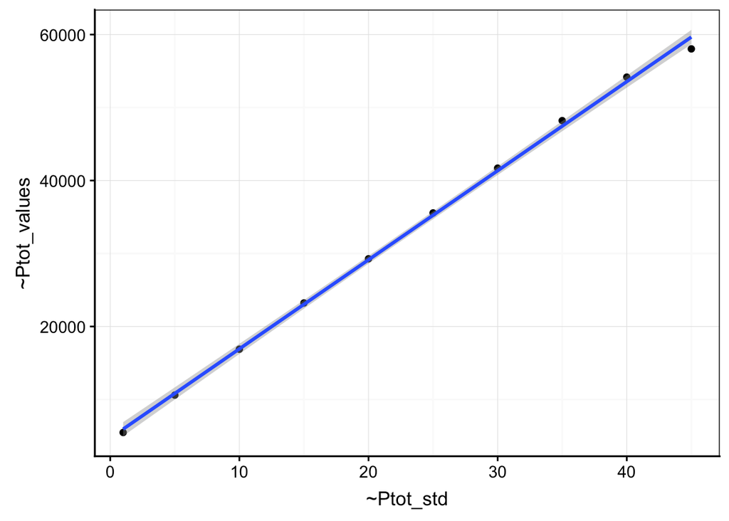

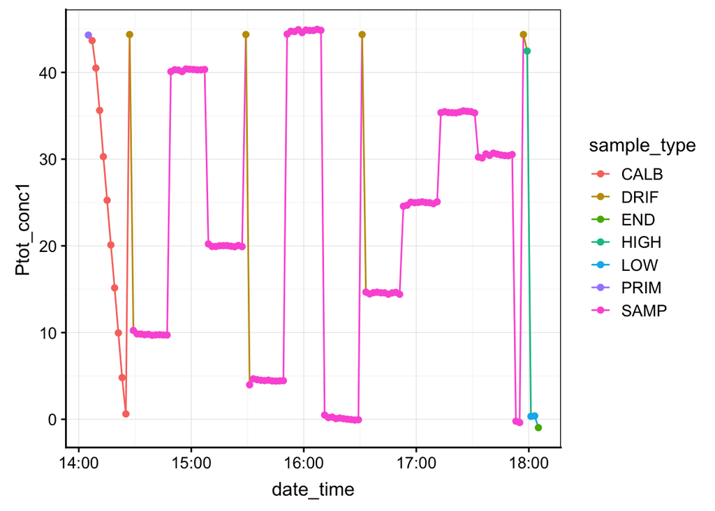

| sample_id | mean | sd | cv | n |
| --- | --- | --- | --- | --- |
| cal1 | 0.1553688 | 0.2257598 | 1.4530573 | 11 |
| cal10 | 9.8238059 | 0.1591417 | 0.0161996 | 11 |
| cal15 | 14.6146447 | 0.2003560 | 0.0137093 | 11 |
| cal20 | 20.0069169 | 0.0970241 | 0.0048495 | 11 |
| cal25 | 24.9575720 | 0.1903334 | 0.0076263 | 11 |
| cal30 | 30.4360080 | 0.1682280 | 0.0055273 | 11 |
| cal35 | 35.4400592 | 0.0971852 | 0.0027422 | 11 |
| cal40 | 40.2991141 | 0.1184794 | 0.0029400 | 11 |
| cal45 | 44.6779010 | 0.3698069 | 0.0082772 | 11 |
| cal5 | 4.4748762 | 0.2052229 | 0.0458611 | 11 |
| mesoA | -0.2166918 | NA | NA | 1 |
| mesoB | -0.3756144 | NA | NA | 1 |